# ENV872 final project

# 5 Exploratory Analysis

The exploratory data analysis (EDA) performed on our dataset involves the utilization of visualizations and summarization methods to gain insight into the dataset’s characteristics and distribution. We first begin with a visualization of facility counts by their primary industry, using a log scale to better represent the vast differences in facility counts among industries. The majority of the facilities are concentrated in industries such as Manufacturing, Utilities, Administrative and Support and Waste Management and Remediation Services, Mining, and Wholesale Trade.

Then we make the next visualizations concentrate on environmental impact rankings of facilities, specifically the greenhouse gas (GHG) and Toxic Release Inventory (TRI) rankings in 2014. These rankings are plotted by the primary industry in a boxplot with jittered points that illustrate the distribution of rankings across industries. A summary table is also included, detailing the count of facilities and the mean rank for each industry in descending order of facility count. The table and plots help identify which industries have the highest environmental impact and those with the greatest variance in environmental impact rankings.

- Below is the visualization of facility counts by their primary industry, using a log scale to better represent the vast differences in facility counts among industries.

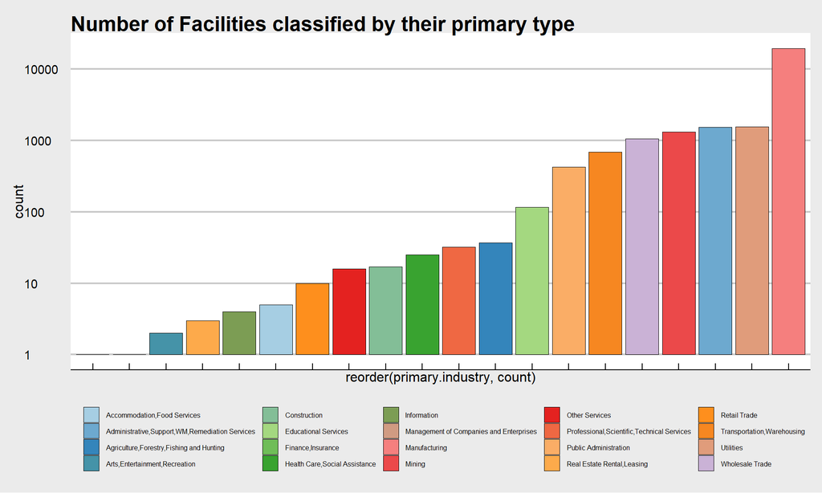

The plot shows that the distribution of facilities across primary industries is highly uneven. The majority of facilities belong to a few industries, such as Manufacturing, Utilities, Administrative and Support and Waste Management and Remediation Services, Mining, and Wholesale Trade. Conversely, the Accommodation, Food Services, Arts, Entertainment, Recreation, Finance, Insurance, and Management of Companies and Enterprises industries have relatively few observations, with less than 10 facilities in each.

- Below is the boxplot of greenhouse gas (GHG) 2014 ranking by the industry caterogy.

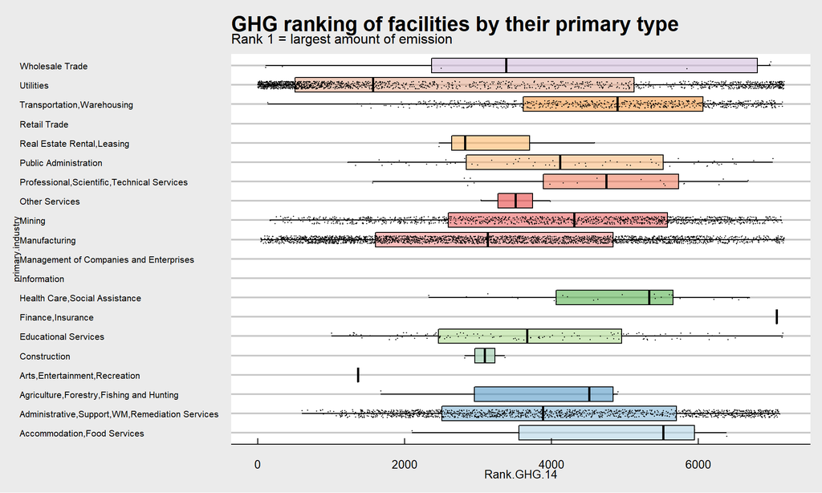

- Below is the table showing the first 6 industry with most counts and their mean rank of green house gas.

| primary.industry | count | meanGHG |
| --- | --- | --- |
| Manufacturing | 2320 | 3266.039 |
| Utilities | 1503 | 2701.919 |
| Administrative,Support,WM,Remediation Services | 1307 | 4045.892 |
| Mining | 1133 | 4073.612 |
| Transportation,Warehousing | 653 | 4795.291 |
| Educational Services | 112 | 3705.384 |

- Below is the boxplot of Toxic Release Inventory (TRI) 2014 ranking by the industry caterogy.

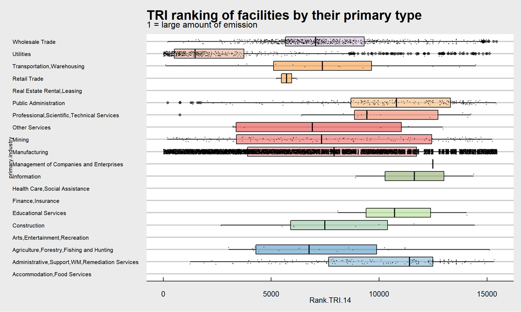

- Below is the table showing the first 6 industry with most counts and their mean rank of Toxic Release Inventory (TRI).

| primary.industry | count | meanGHG |
| --- | --- | --- |
| Manufacturing | 13476 | 7838.367 |
| Wholesale Trade | 803 | 7586.588 |
| Utilities | 546 | 3135.068 |
| Public Administration | 219 | 10385.018 |
| Administrative,Support,WM,Remediation Services | 190 | 10075.368 |
| Mining | 158 | 7740.076 |

# 6 Analysis

## 6.1 Geographical distribution of green house gas emission of year 2014

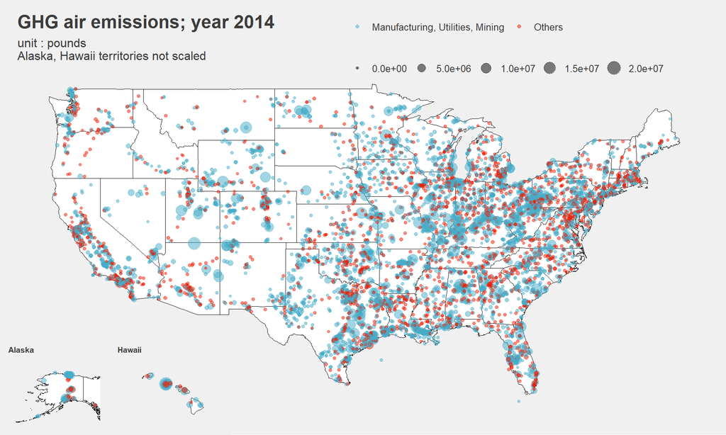

Here we display the geographical distribution of facilities in the US with their greenhouse gas (GHG) direct emissions in 2014, categorized by primary industry. The map is divided into two parts: the mainland US and the Hawaii and Alaska territories. The facilities in Manufacturing, Utilities, and Mining industries are categorized together, while the remaining industries are grouped into the “Others” category. The size of the points represents the magnitude of GHG direct emissions, and the color represents the primary industry category. The legend indicates which color represents each category. Alaska and Hawaii territories are shown on separate maps, as they are not scaled to the mainland US.

The plot reveals that the Manufacturing, Utilities, and Mining industries emit significantly more greenhouse gas compared to other industries, which is consistent with our expectations. Large greenhouse gas emissions are widespread across the United States and could potentially represent power plants. Additionally, regions such as the lake area, Texas, Florida, and the East Coast have higher emissions due to the high concentration of manufacturing industries in these areas.

## 6.2 Geographical distribution of Toxic Release Inventory emission of year 2014

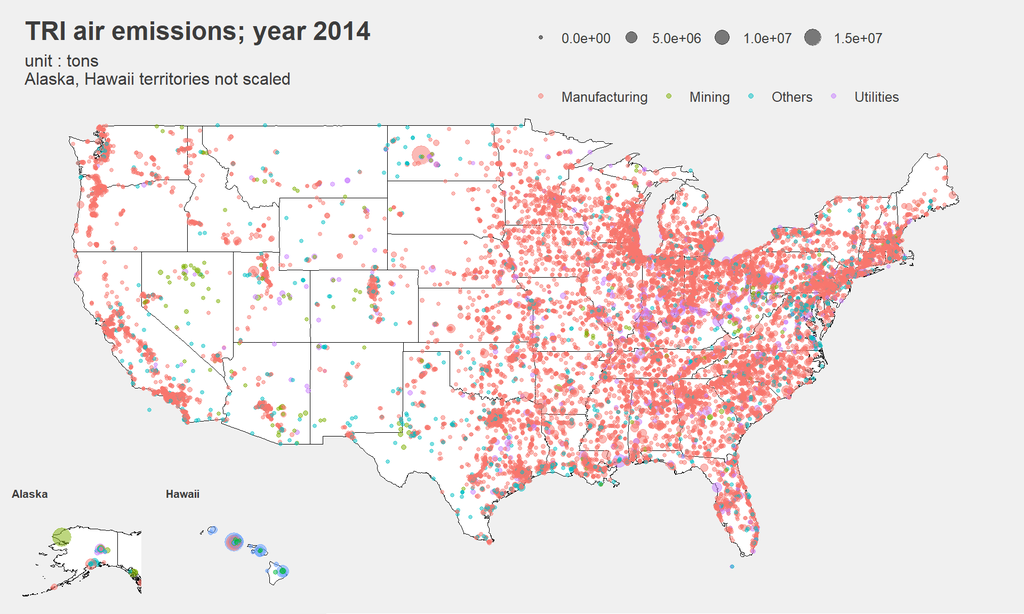

The plot indicates that manufacturing is responsible for the largest Toxic Release Inventory (TRI) air emissions, followed by utilities. Similar to the previous plot, the regions with more industrial activity, such as the Lake area, Texas, Florida, and the East Coast, have higher TRI emissions.

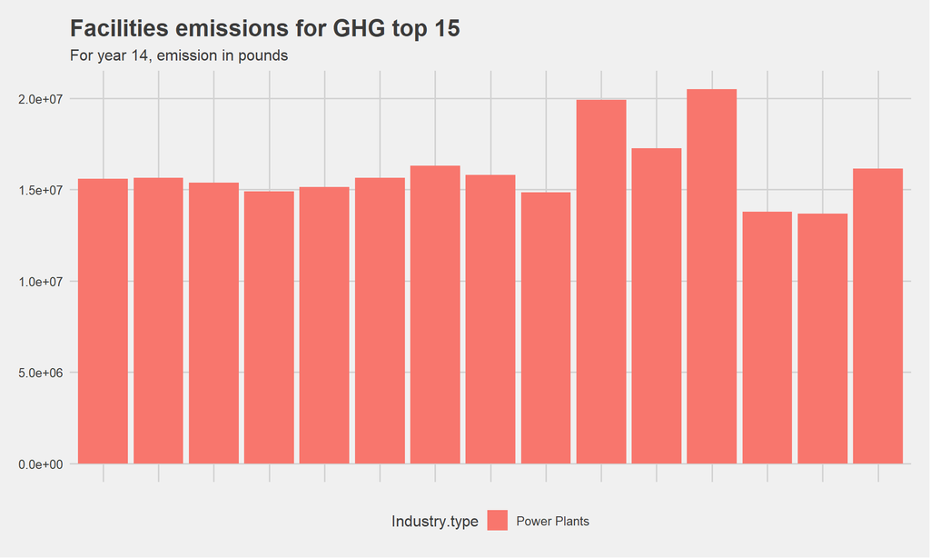

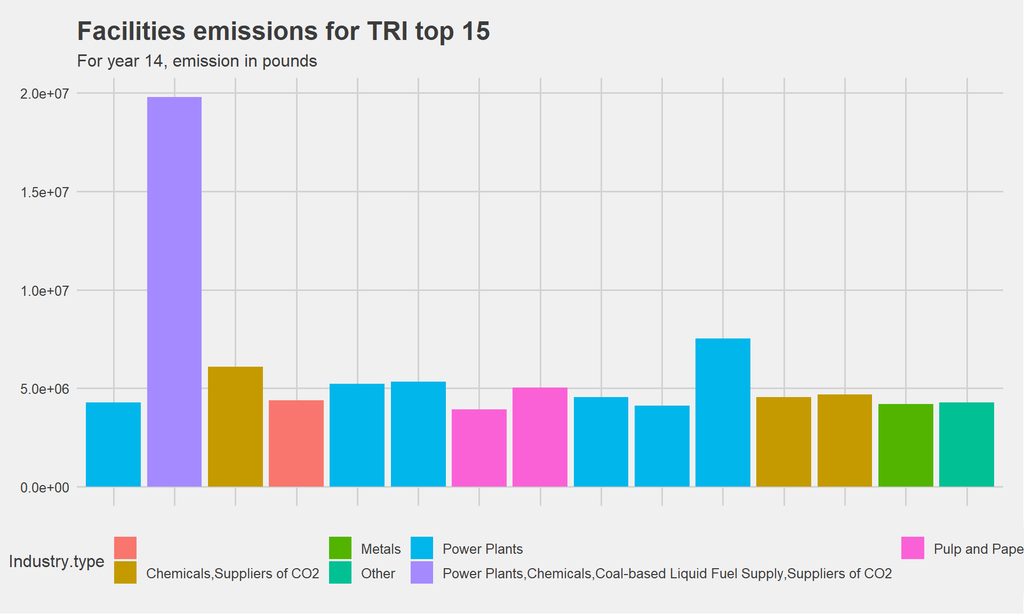

## 6.4 Hypothesis test for emissions across all industries

In order to determine if there is a significant difference in greenhouse gas (GHG) and Toxic Release Inventory (TRI) emissions across all industries, an ANOVA (Analysis of Variance) test can be conducted. The null hypothesis would be that there is no significant difference in GHG or TRI emissions across industries, while the alternative hypothesis would be that at least one industry has a different mean GHG emission than the others. The ANOVA test would require calculating the sum of squares between and within groups to calculate the F-statistic and corresponding p-value. If the p-value is less than the predetermined significance level (such as 0.05), we would reject the null hypothesis and conclude that at least one industry has a different mean GHG emission than the others.

- Green house gas

```
##                    Df    Sum Sq   Mean Sq F value Pr(>F)
## primary.industry   16 1.754e+15 1.096e+14   60.75 <2e-16 ***
## Residuals        7218 1.302e+16 1.804e+12
## ---
## Signif. codes:  0 '***' 0.001 '**' 0.01 '*' 0.05 '.' 0.1 ' ' 1
## 因为不存在，19129个观察量被删除了
```

The resulting P value is smaller than 0.05, thus we can conclude at least one industry type is different from others in GHG emission.

- Toxic Release Inventory

```
##                     Df    Sum Sq   Mean Sq F value Pr(>F)
## primary.industry    15 4.802e+13 3.201e+12   52.67 <2e-16 ***
## Residuals        21709 1.319e+15 6.078e+10
## ---
## Signif. codes:  0 '***' 0.001 '**' 0.01 '*' 0.05 '.' 0.1 ' ' 1
## 因为不存在，4639个观察量被删除了
```

The resulting P value is smaller than 0.05, thus we can conclude at least one industry type is different from others in TRI emission.

## 6.5 The 2010-2014 greenhouse gas (GHG) emission analysis

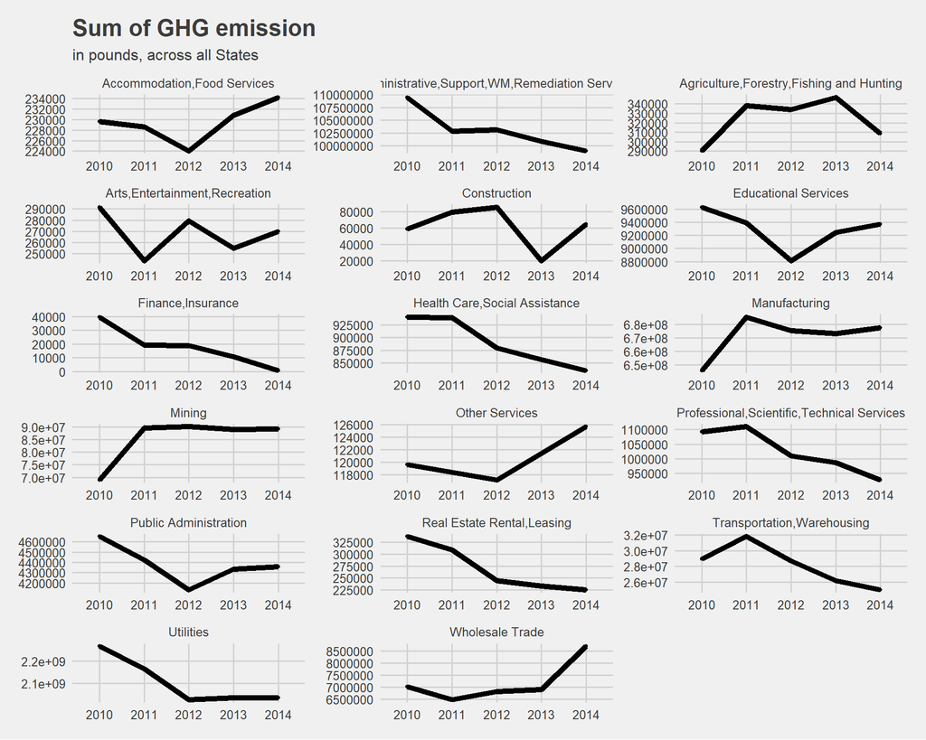

## 6.6 The 2010-2014 Toxic Release Inventory (TRI) emission analysis

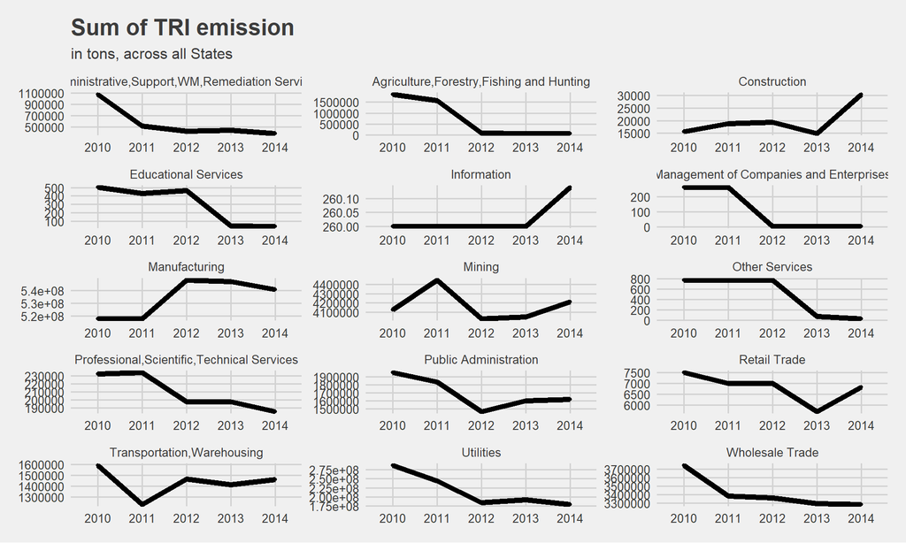

## 6.7 State total emission analysis

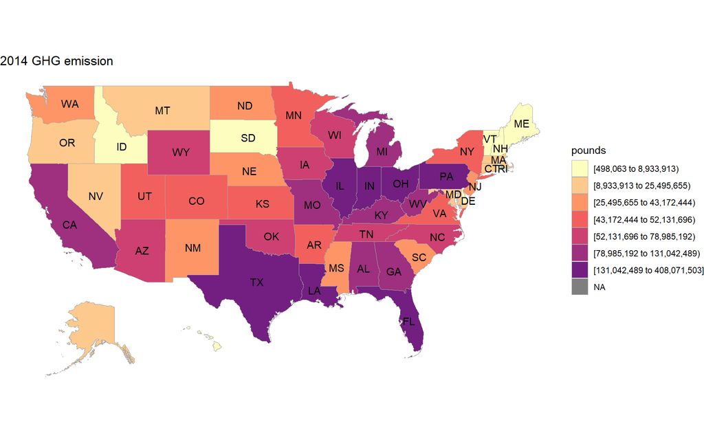

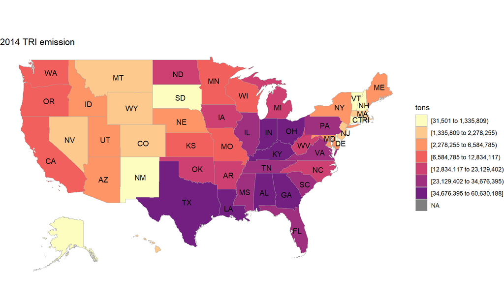

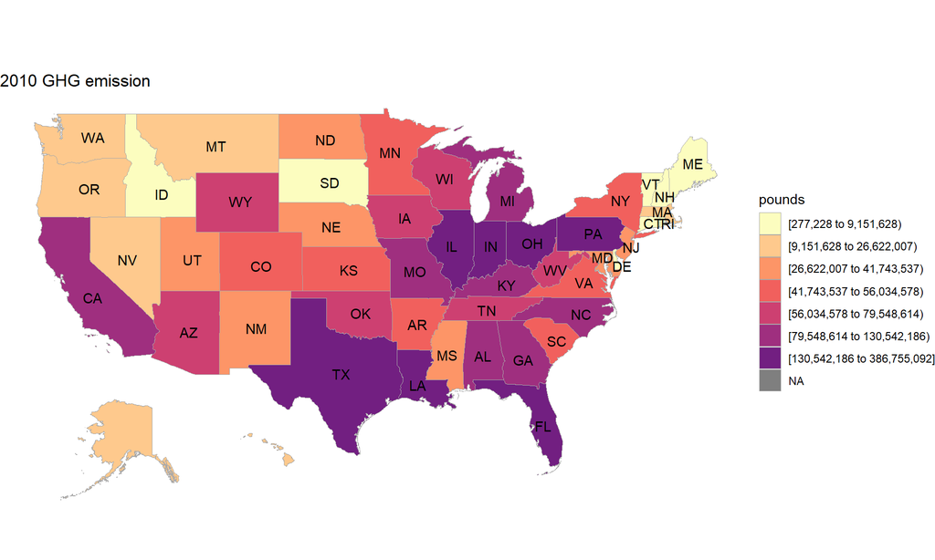

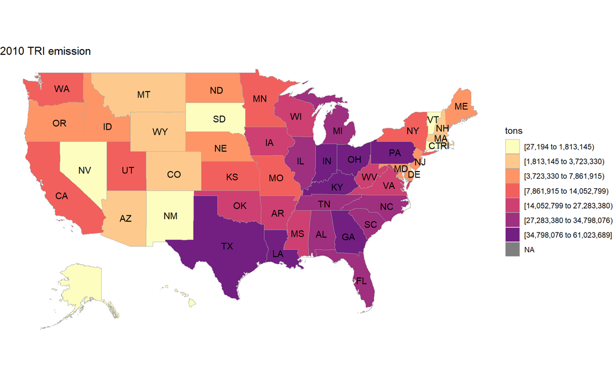

# 7 Summary and Conclusions